# YouTube Trending Videos Exploration

2019/12/16

## Introduction

YouTube is one of the largest video hosting websites in the world, which has profound influences on the society in all aspects. Therefore, analyzing of YouTube’s dataset become significant for advertisers and investors to analyze the social trends and make a prediction for future strategic business planning.

- View Pattern by Country
- User Participation by Country
- Trending Lifecycle

## View Pattern

1.1 Top 5 Most Viewed YouTube Categories (by country)

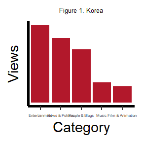

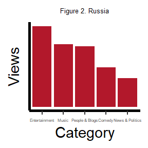

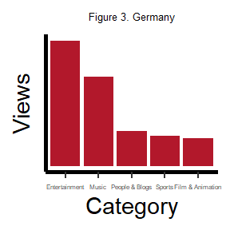

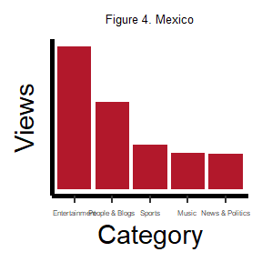

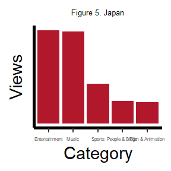

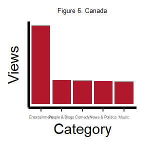

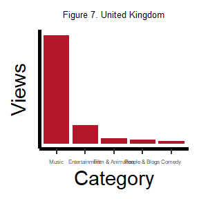

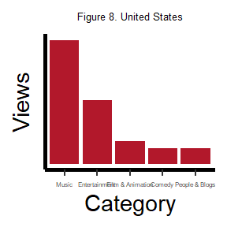

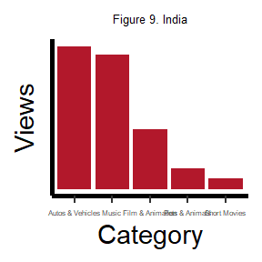

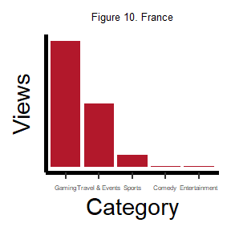

## View Pattern

1.2 Top 5 Most Rated YouTube Categories (by country)

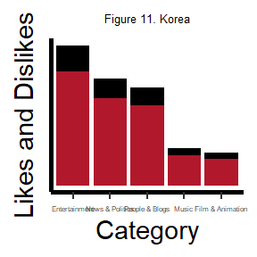

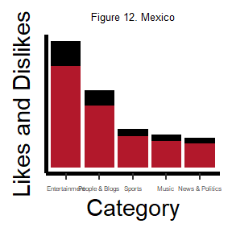

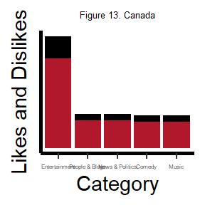

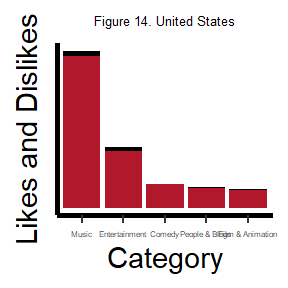

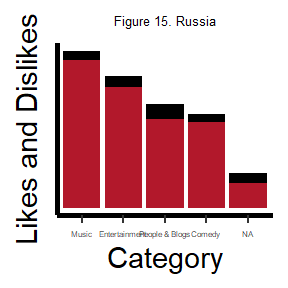

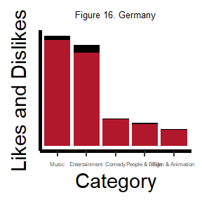

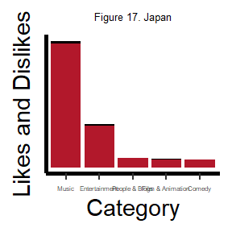

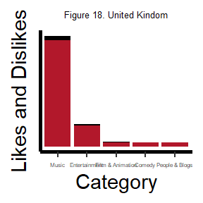

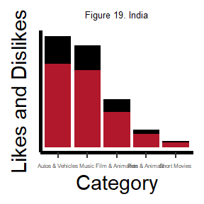

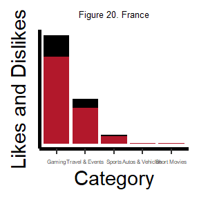

## 1. View pattern

1.3 Top 5 Most Commented YouTube Categories (by country)

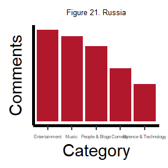

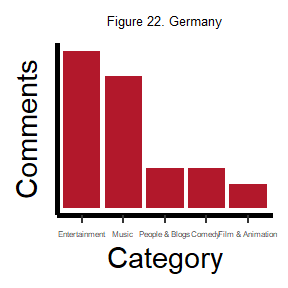

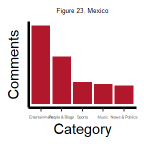

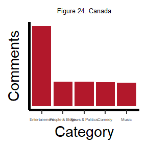

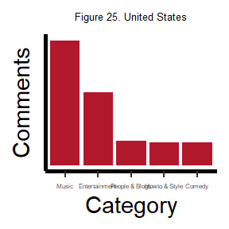

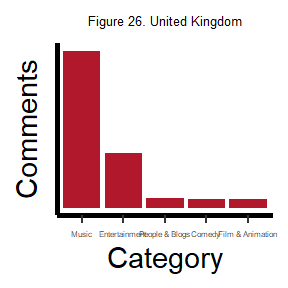

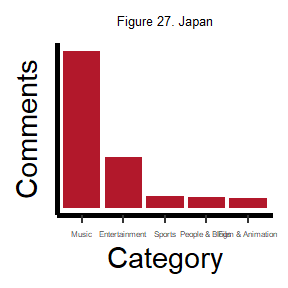

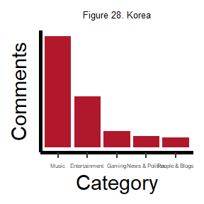

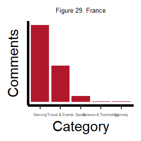

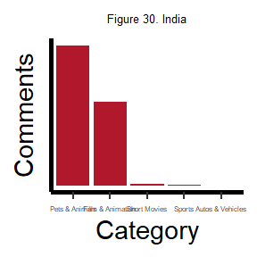

## 1. View pattern

1.4 Top 5 Most Popular YouTube Categories (by country)

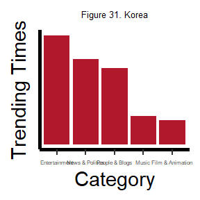

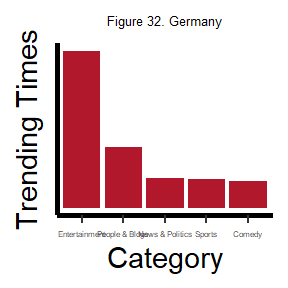

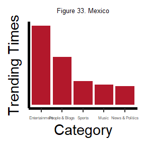

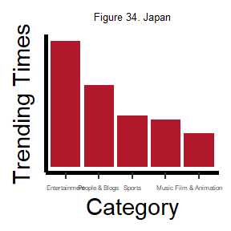

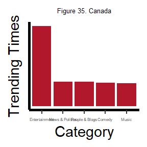

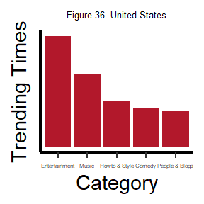

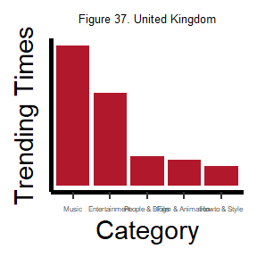

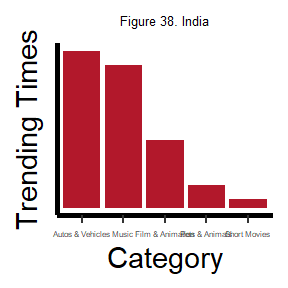

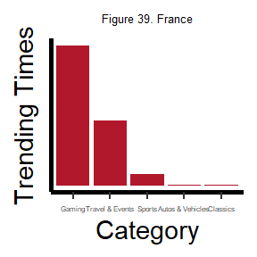

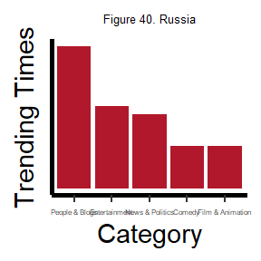

## 2. User participation

Voting Rate

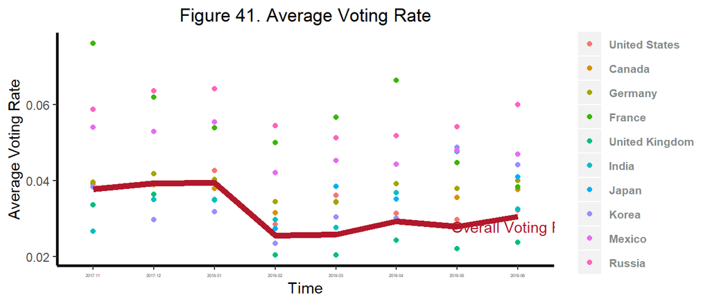